# SOC 325 Lab 7 - Tidycensus

Soc 325: Quantified-Self

2023-11-15

# Preamble before starting the labs

## R packages

```r
## Run this code, to manage packages and install as needed.
# Install pacman
if (!require("pacman")) install.packages("pacman", repos = "http://cran.us.r-project.org")
# p_load function loads packages if installed, or install then loads otherwise
pacman::p_load(tidyverse,tidycensus,tigris,here,kableExtra)

theme_set(theme_minimal())
options(scipen = 999)
knitr::opts_chunk$set(error = TRUE)
```

## API Key

To get started working with **tidycensus**, we need obtain an API key from Census http://api.census.gov/data/key_signup.html.

```r
library(tidycensus)
library(tidyverse)

if (FALSE) {
census_api_key("c0adf5947e546e59f39dc80f1295375f69d950e7", install = TRUE)
# First time, reload your environment so you can use the key without restarting R.
readRenviron("~/.Renviron")
# You can check it with:
Sys.getenv("CENSUS_API_KEY")
}
```

**Recommendation** To keep your census API key secret you can run:

```
library(tidycensus)
census_api_key("ENTER YOUR KEY HERE")
```

In the console and everything will work in R Markdown.

# Census Hiearchies

Aggregate data from the decennial US Census, American Community Survey, and other Census surveys are made available to the public at different *enumeration units*. Enumeration units are geographies at which Census data are tabulated. They include both *legal entities* such as states and counties, and *statistical entities* that are not official jurisdictions but used to standardize data tabulation. The smallest unit at which data are made available from the decennial US Census is the *block,* and the smallest unit available in the ACS is the *block group*, which represents a collection of blocks. Other surveys are generally available at higher levels of aggregation.

Enumeration units represent different levels of the *Census hierarchy.* This hierarchy is summarized in the graphic below (from https://www.census.gov/programs-surveys/geography/guidance/hierarchy.html).

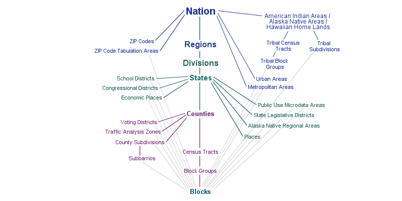

Census hierarchy of enumeration units

The central axis of the diagram represents the central Census hierarchy of enumeration units, as each geography from Census blocks all the way up to the nation *nests* within its parent unit. This means that block groups are fully composed of Census blocks, Census tracts are fully composed of block groups, and so forth.

## Getting data with tidycensus

Retrieving data from census API is possible with the following functions:

- `get_decennial()`, which requests data from the US Decennial Census APIs for 2000, 2010, and 2020.
- `get_acs()`, which requests data from the 1-year and 5-year American Community Survey samples. Data are available from the 1-year ACS back to 2005 and the 5-year ACS back to 2005-2009.
- `get_estimates()`, an interface to the Population Estimates APIs. These datasets include yearly estimates of population characteristics by state, county, and metropolitan area, along with components of change demographic estimates like births, deaths, and migration rates.
- `get_flows()`, an interface to the ACS Migration Flows APIs. Includes information on in- and out-flows from various geographies for the 5-year ACS samples, enabling origin-destination analyses.
- `get_pums()`, which accesses data from the ACS Public Use Microdata Sample APIs. These samples include anonymized individual-level records from the ACS organized by household and are highly useful for many different social science analyses. `get_pums()` will be covered in next week.

To get data from the decennial US Census, users must specify a string representing the requested geography; a vector of Census variable IDs, represented by variable; or optionally a Census table ID, passed to table. In this basic example, let’s look at total population of US states in 2010:

```r
US_pop <- tidycensus::get_decennial(geography = "state",
                       sumfile = "sf1",
                       variables = "P001001",
                       year = 2010)
```

```
## Using Census Summary File 1
```

```r
head(US_pop, 10) %>% kbl()
```

| GEOID | NAME | variable | value |
| --- | --- | --- | --- |
| 01 | Alabama | P001001 | 4779736 |
| 02 | Alaska | P001001 | 710231 |
| 04 | Arizona | P001001 | 6392017 |
| 05 | Arkansas | P001001 | 2915918 |
| 06 | California | P001001 | 37253956 |
| 22 | Louisiana | P001001 | 4533372 |
| 21 | Kentucky | P001001 | 4339367 |
| 08 | Colorado | P001001 | 5029196 |
| 09 | Connecticut | P001001 | 3574097 |
| 10 | Delaware | P001001 | 897934 |

By default, get_decennial() uses the argument `sumfile = "sf1"` which fetches data from the decennial Census Summary File 1. This summary file exists for the 2000 and 2010 decennial US Censuses, and includes core demographic characteristics for Census geographies. There are other summary files designed for various purposes. You can check which summary file exists for which census on [CSSCR.](https://depts.washington.edu/csscr/census/)

As of today, **2020 Decennial Census** data are only available from the PL 94-171 Redistricting summary file, which is specified with `sumfile = "pl"` and include only a limited subset of variables. These variables include total population and housing units; race and ethnicity; voting-age population; and group quarters population. You can find detailed information on [Census website.](https://www.census.gov/programs-surveys/decennial-census/about/rdo/summary-files.html)

For example, the code below retrieves total population of Washington State counties from the 2020 decennial Census:

```r
WA_pop = get_decennial(
  geography = "county",
  state = "WA",
  year = 2020,
  variables = "P1_001N",
  sumfile = "pl")
```

```
## Using the PL 94-171 Redistricting Data Summary File
```

```
## Note: 2020 decennial Census data use differential privacy, a technique that
## introduces errors into data to preserve respondent confidentiality.
## ℹ Small counts should be interpreted with caution.
## ℹ See https://www.census.gov/library/fact-sheets/2021/protecting-the-confidentiality-of-the-2020-census-redistricting-data.html for additional guidance.
```

```r
head(WA_pop, 10) %>% kbl()
```

| GEOID | NAME | variable | value |
| --- | --- | --- | --- |
| 53001 | Adams County, Washington | P1_001N | 20613 |
| 53003 | Asotin County, Washington | P1_001N | 22285 |
| 53005 | Benton County, Washington | P1_001N | 206873 |
| 53007 | Chelan County, Washington | P1_001N | 79074 |
| 53009 | Clallam County, Washington | P1_001N | 77155 |
| 53011 | Clark County, Washington | P1_001N | 503311 |
| 53013 | Columbia County, Washington | P1_001N | 3952 |
| 53015 | Cowlitz County, Washington | P1_001N | 110730 |
| 53017 | Douglas County, Washington | P1_001N | 42938 |
| 53019 | Ferry County, Washington | P1_001N | 7178 |

The function returns a tibble with four columns by default:

- `GEOID`, an identifier for the geographical unit associated with the row.
- `NAME`, a descriptive name of the geographical unit.
- `variable`, the Census variable represented in the row.
- `value`, the value of the variable for that unit.

## Searching for variables

Getting variables from the Census or ACS requires knowing the variable ID - and there are thousands of these IDs across the different Census files. Luckily, tidycensus includes `load_variables()` function. It takes two required and one optional arguments:

- the year of the Census or end year of the ACS sample.
- dataset name, which varies in availability by year (e.g. “pl”, “sf1”).
- (Optional) `cache = TRUE` will cache the dataset on your computer for future use.

To browse these variables, you can either assign the result of this function to a variable and use the `View` function in RStudio. Alternatively, you can use simple regex lookup to extract relevant variables. As an example, this code extracts race and ethnicity population totals from 2020 census.

```r
vars = load_variables(2020, "pl", cache = TRUE)
#View(vars)

race_vars_tbl = vars %>%
  filter(str_detect(name, "01N|02N")) %>%
  filter(str_detect(concept, "RACE"))

race_totals = race_vars_tbl$name
names(race_totals) = str_c(race_vars_tbl$label, race_vars_tbl$concept, sep = "_")

race_vars_tbl%>%kableExtra::kbl()
```

| name | label | concept |
| --- | --- | --- |
| P1_001N | !!Total: | RACE |
| P1_002N | !!Total:!!Population of one race: | RACE |
| P2_001N | !!Total: | HISPANIC OR LATINO, AND NOT HISPANIC OR LATINO BY RACE |
| P2_002N | !!Total:!!Hispanic or Latino | HISPANIC OR LATINO, AND NOT HISPANIC OR LATINO BY RACE |
| P3_001N | !!Total: | RACE FOR THE POPULATION 18 YEARS AND OVER |
| P3_002N | !!Total:!!Population of one race: | RACE FOR THE POPULATION 18 YEARS AND OVER |
| P4_001N | !!Total: | HISPANIC OR LATINO, AND NOT HISPANIC OR LATINO BY RACE FOR THE POPULATION 18 YEARS AND OVER |
| P4_002N | !!Total:!!Hispanic or Latino | HISPANIC OR LATINO, AND NOT HISPANIC OR LATINO BY RACE FOR THE POPULATION 18 YEARS AND OVER |

## Working with ACS data

American Community Survey (ACS) data are available from the 1-year ACS since 2005 for geographies of population 65,000 and greater, and from the 5-year ACS for all geographies down to the block group level starting with the 2005-2009 dataset. `get_acs()` defaults to the 5-year ACS with the argument `survey = "acs5"`, but 1-year ACS data are available using `survey = "acs1"`.

ACS data differ from decennial Census data as they are based on an annual sample of approximately 3 million households, rather than a more complete enumeration of the US population. In turn, ACS data points are **estimates** characterized by a **margin of error**. **tidycensus** will always return the estimate and margin of error together for any requested variables when using `get_acs()`. In turn, when requesting ACS data with **tidycensus**, it is not necessary to specify the `"E"` or `"M"` suffix for a variable name. Let’s fetch median household income data from the 2014-2018 ACS for counties in Vermont.

```r
vt <- get_acs(geography = "county",
              variables = c(medincome = "B19013_001"),
              state = "VT",
              year = 2018)
vt
```

```
## # A tibble: 14 × 5
##    GEOID NAME                       variable  estimate   moe
##    <chr> <chr>                      <chr>        <dbl> <dbl>
##  1 50001 Addison County, Vermont    medincome    65093  2424
##  2 50003 Bennington County, Vermont medincome    53040  2307
##  3 50005 Caledonia County, Vermont  medincome    49348  1842
##  4 50007 Chittenden County, Vermont medincome    69896  2132
##  5 50009 Essex County, Vermont      medincome    41045  2661
##  6 50011 Franklin County, Vermont   medincome    64258  1568
##  7 50013 Grand Isle County, Vermont medincome    69583  5812
##  8 50015 Lamoille County, Vermont   medincome    60365  3915
##  9 50017 Orange County, Vermont     medincome    60159  2361
## 10 50019 Orleans County, Vermont    medincome    47915  2193
## 11 50021 Rutland County, Vermont    medincome    54973  1754
## 12 50023 Washington County, Vermont medincome    62108  2065
## 13 50025 Windham County, Vermont    medincome    52659  1706
## 14 50027 Windsor County, Vermont    medincome    58303  1576
```

The output is similar to a call to `get_decennial()`, but instead of a `value` column, `get_acs` returns `estimate` and `moe` columns for the ACS estimate and margin of error, respectively. `moe` represents the default 90 percent confidence level around the estimate; this can be changed to 95 or 99 percent with the `moe_level` parameter in `get_acs` if desired.

As we have the margin of error, we can visualize the uncertainty around the estimate:

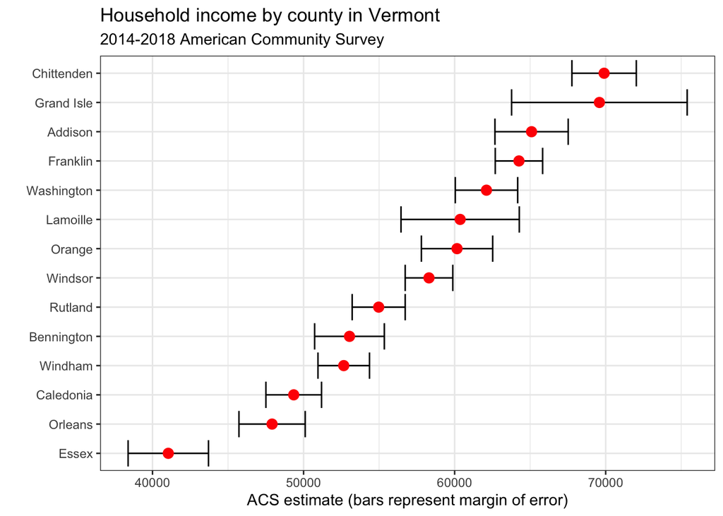

```r
vt %>%
  mutate(NAME = gsub(" County, Vermont", "", NAME)) %>%
  ggplot(aes(x = estimate, y = reorder(NAME, estimate))) +
  geom_errorbarh(aes(xmin = estimate - moe, xmax = estimate + moe)) +
  geom_point(color = "red", size = 3) +
  labs(title = "Household income by county in Vermont",
       subtitle = "2014-2018 American Community Survey",
       y = "",
       x = "ACS estimate (bars represent margin of error)") +
  theme_bw()
```

# Case Study 1: Racial and Ethnic composition of WA counties

First, let’s do a quick sanity check on the various total population variables. Also, checking the relative proportions of one race and multiple race populations. Using King County as an example:

```r
king_race = get_decennial(
  geography = "county",
  state = "WA",
  county = "King",
  year = 2020,
  variables = race_totals,
  summary_var = "P1_001N", # total population
  sumfile = "pl")
```

```
## Using the PL 94-171 Redistricting Data Summary File
```

```r
king_race %>%
  mutate(percent = round(100 * (value / summary_value)),1) %>%
  select(variable, value, percent) %>%
  kbl()
```

| variable | value | percent |
| --- | --- | --- |
| !!Total:_RACE | 2269675 | 100 |
| !!Total:!!Population of one race:_RACE | 2033922 | 90 |
| !!Total:_HISPANIC OR LATINO, AND NOT HISPANIC OR LATINO BY RACE | 2269675 | 100 |
| !!Total:!!Hispanic or Latino_HISPANIC OR LATINO, AND NOT HISPANIC OR LATINO BY RACE | 243021 | 11 |
| !!Total:_RACE FOR THE POPULATION 18 YEARS AND OVER | 1813470 | 80 |
| !!Total:!!Population of one race:_RACE FOR THE POPULATION 18 YEARS AND OVER | 1661181 | 73 |
| !!Total:_HISPANIC OR LATINO, AND NOT HISPANIC OR LATINO BY RACE FOR THE POPULATION 18 YEARS AND OVER | 1813470 | 80 |
| !!Total:!!Hispanic or Latino_HISPANIC OR LATINO, AND NOT HISPANIC OR LATINO BY RACE FOR THE POPULATION 18 YEARS AND OVER | 169834 | 7 |

As seen the table above, people who are 2 or more race consist of around 10%. We will ignore them in this tutorial for simplicity, but with some data wrangling, they can easily be lumped to a seperate category.

```r
# race and ethnicity variables
race_vars <- c(
  Hispanic = "P2_002N",
  White = "P2_005N",
  Black = "P2_006N",
  Native = "P2_007N",
  Asian = "P2_008N",
  NHPI = "P2_009N",
  Other = "P2_010N"
  )
```

```r
WA_raw = get_decennial(
  geography = "county",
  state = "WA",
  year = 2020,
  variables = race_vars,
  summary_var = "P1_001N",  # total population
  sumfile = "pl")
```

```
## Using the PL 94-171 Redistricting Data Summary File
```

We can use tidyverse pipeline to clean and prepare our data. The most important step below is to make sure county names match with the names in the `us_wa_counties_grid1` from geofacet package.

```r
WA_race =  WA_raw %>%
  rename(total_pop = summary_value, pop=value) %>%
  mutate(county = str_remove(NAME, " County, Washington")) %>%
  mutate(race = as_factor(variable)) %>%
  mutate(percent = round(100 * (pop / total_pop), 1)) %>%
  select(county, race, pop, total_pop, percent)


head(WA_race, 10) %>% kbl()
```

| county | race | pop | total_pop | percent |
| --- | --- | --- | --- | --- |
| Adams | Hispanic | 13120 | 20613 | 63.6 |
| Asotin | Hispanic | 915 | 22285 | 4.1 |
| Benton | Hispanic | 49339 | 206873 | 23.8 |
| Chelan | Hispanic | 22104 | 79074 | 28.0 |
| Clallam | Hispanic | 4732 | 77155 | 6.1 |
| Clark | Hispanic | 58790 | 503311 | 11.7 |
| Columbia | Hispanic | 304 | 3952 | 7.7 |
| Cowlitz | Hispanic | 10802 | 110730 | 9.8 |
| Douglas | Hispanic | 14637 | 42938 | 34.1 |
| Ferry | Hispanic | 210 | 7178 | 2.9 |

By default tidycensus creates a tidy data.frame, each row represents county-characteristic combinations. Alternatively, we can create a table of variables spread across the columns by the setting `output = "wide"`. Here is the same data in a wide form:

```r
WA_wide = get_decennial(
  geography = "county",
  state = "WA",
  year = 2020,
  variables = race_vars,
  summary_var = "P1_001N",  # total population
  sumfile = "pl",
  output = "wide")
```

```
## Using the PL 94-171 Redistricting Data Summary File
```

```r
head(WA_wide, 10) %>% kbl()
```

| GEOID | NAME | Hispanic | White | Black | Native | Asian | NHPI | Other | summary_value |
| --- | --- | --- | --- | --- | --- | --- | --- | --- | --- |
| 53001 | Adams County, Washington | 13120 | 6829 | 24 | 63 | 129 | 3 | 87 | 20613 |
| 53003 | Asotin County, Washington | 915 | 19473 | 113 | 262 | 206 | 34 | 88 | 22285 |
| 53005 | Benton County, Washington | 49339 | 135718 | 2621 | 1191 | 6244 | 536 | 1049 | 206873 |
| 53007 | Chelan County, Washington | 22104 | 52093 | 253 | 408 | 787 | 109 | 381 | 79074 |
| 53009 | Clallam County, Washington | 4732 | 61164 | 571 | 3931 | 1234 | 113 | 432 | 77155 |
| 53011 | Clark County, Washington | 58790 | 366727 | 10850 | 3051 | 23910 | 5127 | 2536 | 503311 |
| 53013 | Columbia County, Washington | 304 | 3347 | 6 | 41 | 21 | 0 | 18 | 3952 |
| 53015 | Cowlitz County, Washington | 10802 | 88067 | 746 | 1409 | 1721 | 643 | 485 | 110730 |
| 53017 | Douglas County, Washington | 14637 | 25445 | 117 | 338 | 406 | 55 | 203 | 42938 |
| 53019 | Ferry County, Washington | 210 | 5056 | 21 | 1293 | 43 | 11 | 36 | 7178 |

I will move forward with the tidy data.frame, as it is generally easier to work with within the tidyverse. For instance, we can easily look at the top 20 counties with most non-white population:

```r
WA_race %>%
  filter(race != "White") %>%
  group_by(county, nonWhite = race) %>%
  summarise(percantage = max(percent)) %>%
  arrange(-percantage) %>%
  head(20) %>%
  kbl()
```

| county | nonWhite | percantage |
| --- | --- | --- |
| Adams | Hispanic | 63.6 |
| Franklin | Hispanic | 54.2 |
| Yakima | Hispanic | 50.7 |
| Grant | Hispanic | 42.8 |
| Douglas | Hispanic | 34.1 |
| Chelan | Hispanic | 28.0 |
| Benton | Hispanic | 23.8 |
| Walla Walla | Hispanic | 22.7 |
| King | Asian | 19.8 |
| Okanogan | Hispanic | 19.5 |
| Skagit | Hispanic | 18.4 |
| Ferry | Native | 18.0 |
| Klickitat | Hispanic | 12.8 |
| Snohomish | Asian | 12.2 |
| Pierce | Hispanic | 12.1 |
| Clark | Hispanic | 11.7 |
| Mason | Hispanic | 11.6 |
| Snohomish | Hispanic | 11.6 |
| Okanogan | Native | 10.9 |
| King | Hispanic | 10.7 |

```r
library(geofacet)
```

```
## Note: the specified label = 'county' does not exist in the supplied
##   grid and it will be ignored.
```

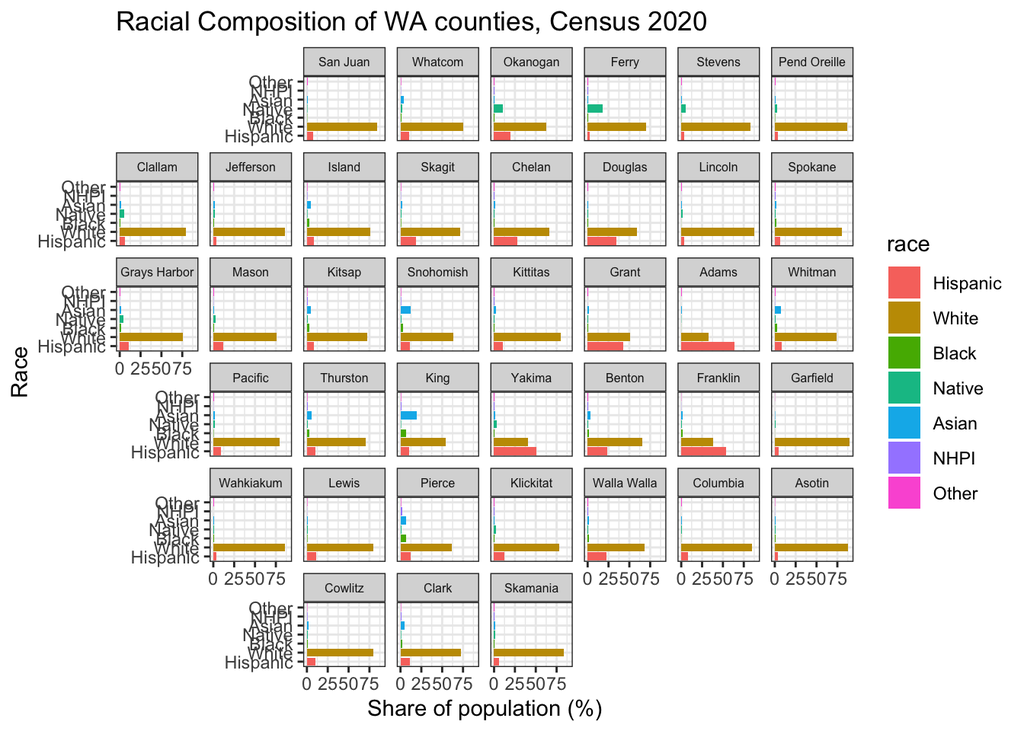

```r
WA_race %>%
  ggplot(aes(percent, race, fill=race)) +
  geom_col() +
  theme_bw() +
  facet_geo(~ county, grid = "us_wa_counties_grid1", label = "county") +
  labs(title = "Racial Composition of WA counties, Census 2020",
    x = "Share of population (%)",
    y = "Race") +
  theme(strip.text.x = element_text(size = 6))
```

# Case Study 2: Population characteristics of Yakima county

We will use `get_estimates()` to get data from the US Census Bureau Population Estimates API. From the product argument we will choose `"characteristics"`. It returns population estimates broken down by categories of `AGEGROUP`, `SEX`, `RACE`, and `HISP`, for Hispanic origin. Requested breakdowns should be specified as a character vector supplied to the `breakdown` parameter.

Census bureau normally use integer labels for the breakdown variables. Luckily, specifying `breakdown_labels = TRUE`, the function will return the text labels instead. For example:

```r
yakima_pop <- get_estimates(geography = "county",
                        product = "characteristics",
                        breakdown = c("SEX", "AGEGROUP", "HISP"),
                        breakdown_labels = TRUE,
                        state = "WA",
                        county = "Yakima")

head(yakima_pop,20) %>% kbl()
```

| GEOID | NAME | year | SEX | AGEGROUP | HISP | value |
| --- | --- | --- | --- | --- | --- | --- |
| 53077 | Yakima County, Washington | 2022 | Male | All ages | Both Hispanic Origins | 129183 |
| 53077 | Yakima County, Washington | 2022 | Male | All ages | Non-Hispanic | 60160 |
| 53077 | Yakima County, Washington | 2022 | Male | All ages | Hispanic | 69023 |
| 53077 | Yakima County, Washington | 2022 | Male | Age 0 to 4 years | Both Hispanic Origins | 9465 |
| 53077 | Yakima County, Washington | 2022 | Male | Age 0 to 4 years | Non-Hispanic | 2750 |
| 53077 | Yakima County, Washington | 2022 | Male | Age 0 to 4 years | Hispanic | 6715 |
| 53077 | Yakima County, Washington | 2022 | Male | Age 5 to 9 years | Both Hispanic Origins | 10504 |
| 53077 | Yakima County, Washington | 2022 | Male | Age 5 to 9 years | Non-Hispanic | 3368 |
| 53077 | Yakima County, Washington | 2022 | Male | Age 5 to 9 years | Hispanic | 7136 |
| 53077 | Yakima County, Washington | 2022 | Male | Age 10 to 14 years | Both Hispanic Origins | 11225 |
| 53077 | Yakima County, Washington | 2022 | Male | Age 10 to 14 years | Non-Hispanic | 3658 |
| 53077 | Yakima County, Washington | 2022 | Male | Age 10 to 14 years | Hispanic | 7567 |
| 53077 | Yakima County, Washington | 2022 | Male | Age 15 to 19 years | Both Hispanic Origins | 10581 |
| 53077 | Yakima County, Washington | 2022 | Male | Age 15 to 19 years | Non-Hispanic | 3415 |
| 53077 | Yakima County, Washington | 2022 | Male | Age 15 to 19 years | Hispanic | 7166 |
| 53077 | Yakima County, Washington | 2022 | Male | Age 20 to 24 years | Both Hispanic Origins | 9485 |
| 53077 | Yakima County, Washington | 2022 | Male | Age 20 to 24 years | Non-Hispanic | 3335 |
| 53077 | Yakima County, Washington | 2022 | Male | Age 20 to 24 years | Hispanic | 6150 |
| 53077 | Yakima County, Washington | 2022 | Male | Age 25 to 29 years | Both Hispanic Origins | 8896 |
| 53077 | Yakima County, Washington | 2022 | Male | Age 25 to 29 years | Non-Hispanic | 3523 |

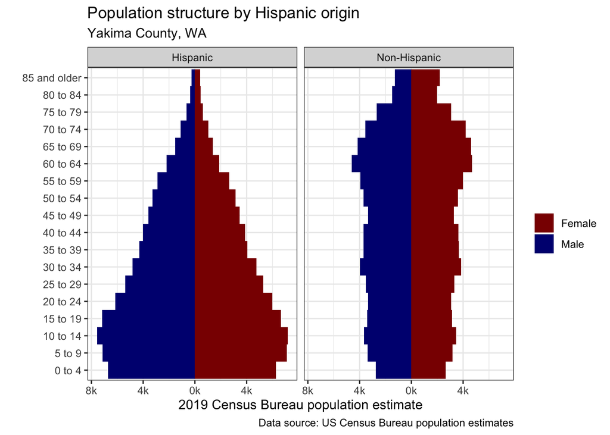

```r
compare <- yakima_pop %>%
  filter(str_detect(AGEGROUP, "^Age"),
                  HISP != "Both Hispanic Origins",
                  SEX != "Both sexes") %>%
  mutate(value = ifelse(SEX == "Male", -value, value))

ggplot(compare, aes(x = AGEGROUP, y = value, fill = SEX)) +
  geom_bar(stat = "identity", width = 1) +
  scale_y_continuous(labels = function(y) paste0(abs(y / 1000), "k")) +
  scale_x_discrete(labels = function(x) gsub("Age | years", "", x)) +
  scale_fill_manual(values = c("darkred", "navy")) +
  coord_flip() +
  theme_bw() +
  facet_wrap(~HISP) +
  labs(x = "",
       y = "2019 Census Bureau population estimate",
       title = "Population structure by Hispanic origin",
       subtitle = "Yakima County, WA",
       fill = "",
       caption = "Data source: US Census Bureau population estimates")
```

# Mapping the US Census Data

#### MAUP Rules Everything Around Me

##### The Modifiable Areal Unit Problem, Visualized

The scale of geography you use determines its context; as you might intuit, looking at some variable at the state-level might yield different apparent results than if you were to look at the same variable at the county-level in that same state. By extension, if you were to make assumptions about the context and wider applicability of your findings using state-level data and results, and assume these could be used to represent county-level variability and context, you might easily misrepresent the true nature of the geographic surface of whatever variable or outcome you are considering. This abstraction probably sounds familiar; it is a geographic extension of the ecological fallacy called the modifiable areal unit problem (MAUP). MAUP is perhaps the ultimate form of geographic data caveat indagator (“researcher beware”); be extremely thoughtful in your choice of geographic level within the limitations of the data to which you have access.

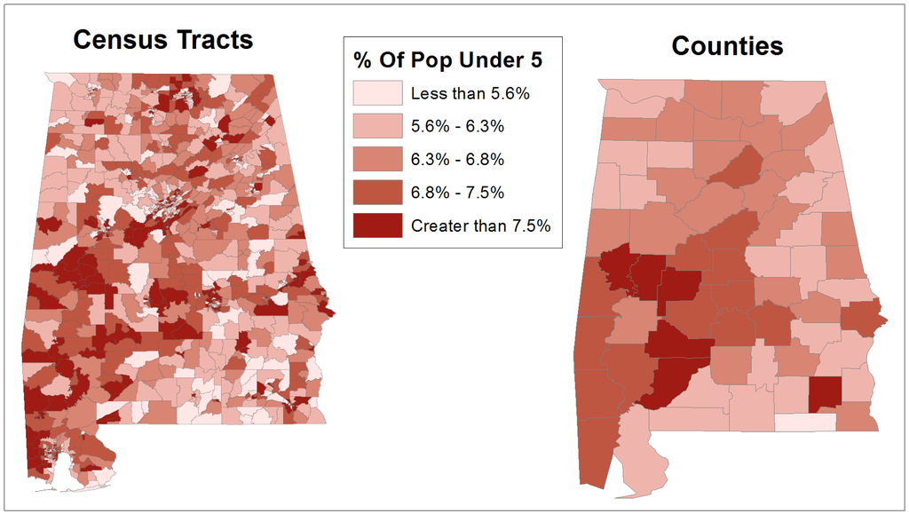

MAUP Example

Another perhaps more familiar example of MAUP in action is this classic gerrymandering diagram representing an imaginary congressional district:

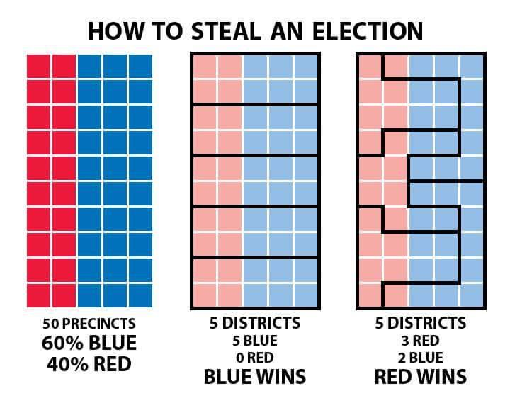

Gerrymandering

And so, in some sense, MAUP does to some degree “rule” everything around us. It is everywhere. It behooves us to try to avoid its worst issues.

#### A word of warning: ZIP codes vs ZCTA

While a lot of research likes to use “ZIP code” as though it is a geographic area level, a ZIP code is not a true geography. ZIP codes are used by the United States Post Office to determine the relative delivery volume load of a specific post office; this has no inherent geographic bound and is fluid. If a ZIP code is tied to a post office, it is then an example of point data (which we do not explore in this tutorial). To look at ZIP codes as if they were true geographic areas, the Census Bureau regularly publishes ZCTA (ZIP Code Tabulation Area) spatial files. In order to consider ZIP code-level data, you will need to “crosswalk” the ZIP code to its approximate ZCTA using a crosswalk file (i.e. you have to link them). While we are not going to cover this today (it is tricky), you might consider reading about it in [this article about the process](https://mcdc.missouri.edu/geography/ZIP-resources.html), and you can find crosswalk files online through [the huduser.gov website](https://www.huduser.gov/portal/datasets/usps_crosswalk.html#codebook).

### Mapping using tidycensus and ggplot2

Note 1: I am presuming you have both tidycensus installed, and a unique individual Census API key considering you learned about tidycensus last week, too.

Note 2: We are making “choropleth” maps today; this means we are making “fill” maps, or maps that have full areas coloured in by processing area-level continuous or categorical data, instead of using data relating to points on a map (e.g. latitude/longitude of post offices, etc.). This is most appropriate for aggregate data representation in geographic space.

#### Geographic Identifiers (GEOIDs): a brief overview

GEOIDs are assigned to facilitate the presentation, organization and sharing of geographic and statistical data. GEOIDs are numeric codes; for the most part, each geography has its own unique code to differentiate it from all others. The most common GEOIDs you will see relate to states, counties, congressional districts, core based statistical areas (metropolitan and micropolitan areas; CBSAs), census tracts, block groups and census blocks. Note: If the geographies nest (remember the hierarchy!) then the codes are iteratively built.

[output not shown]

Another form of GEOID is FIPS codes (Federal Information Processing Series codes); often when someone refers to a FIPS code, they are referring to a specific county’s code, but not always.

[You can read more about FIPS codes here.](https://www.census.gov/library/reference/code-lists/ansi.html)  
[You can read more about GEOIDs here.](https://www.census.gov/programs-surveys/geography/guidance/geo-identifiers.html)

#### Getting geometry files through tidycensus

Given that census data relates to specific areas on a map, you might want to map these yourself. Fortunately, **tidycensus** uses **tigris** package to make this a reasonably straight-forward process. With a simple specification, **tidycensus** is able to return simple feature (i.e. sf) geometry for geographic units in addition to variables from the Decennial US Census (the Census) or American Community Survey (the ACS). By setting `geometry = TRUE` in a **tidycensus** function call, **tidycensus** will use the **tigris** package to retrieve the corresponding geographic dataset from the US Census Bureau and pre-merge it with the tabular data obtained from the Census API.

The following example shows median household income from the 2016-2020 5-year ACS for Census tracts in King County, Washington:

```r
king <- get_acs(state = "WA",
                  county = "King",
                  geography = "tract",
                  variables = "B19013_001",
                  geometry = TRUE, #when you set it to TRUE you get a geometry column
                  year = 2020)
head(king)
```

```
## Simple feature collection with 6 features and 5 fields
## Geometry type: MULTIPOLYGON
## Dimension:     XY
## Bounding box:  xmin: -122.2305 ymin: 47.29001 xmax: -122.1285 ymax: 47.77669
## Geodetic CRS:  NAD83
##         GEOID                                         NAME   variable estimate
## 1 53033024400    Census Tract 244, King County, Washington B19013_001   108750
## 2 53033025806 Census Tract 258.06, King County, Washington B19013_001    91406
## 3 53033021803 Census Tract 218.03, King County, Washington B19013_001   103871
## 4 53033031908 Census Tract 319.08, King County, Washington B19013_001    82331
## 5 53033022703 Census Tract 227.03, King County, Washington B19013_001   136591
## 6 53033030700    Census Tract 307, King County, Washington B19013_001    49583
##     moe                       geometry
## 1 24895 MULTIPOLYGON (((-122.2299 4...
## 2 15107 MULTIPOLYGON (((-122.2179 4...
## 3 15227 MULTIPOLYGON (((-122.2232 4...
## 4 15307 MULTIPOLYGON (((-122.1539 4...
## 5 45143 MULTIPOLYGON (((-122.1872 4...
## 6  9233 MULTIPOLYGON (((-122.2289 4...
```

Our object `king` looks much like the basic **tidycensus** output, but with a `geometry` list-column describing the geometry of each feature, using the geographic coordinate system NAD 1983 (EPSG: 4269) which is the default for Census shapefiles. **tidycensus** uses the Census [cartographic boundary shapefiles](https://www.census.gov/geographies/mapping-files/time-series/geo/carto-boundary-file.html) for faster processing (usually good enough for most purposes); if you prefer the TIGER/Line shapefiles, set `cb = FALSE` in the function call. A word of warning: these TIGER/Line shapefiles are sometimes huge because they have a lot of information beyond map lines. I wouldn’t bother using these unless you have a specific need (e.g. you want to superimpose roads on your map, etc.) or you’ll be waiting for your map to load for ages!

Also, TIGER/Line shapefiles spit out something like on the left, whereas we probably want something more like on the right:

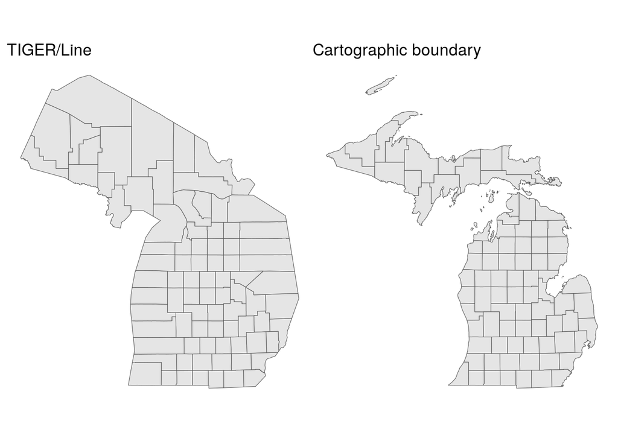

compare TIGER/Line to multipolygon

To return to our geometry focus: As the dataset is in a tidy format, it can be quickly visualized with the `geom_sf` functionality currently in the development version of **ggplot2**:

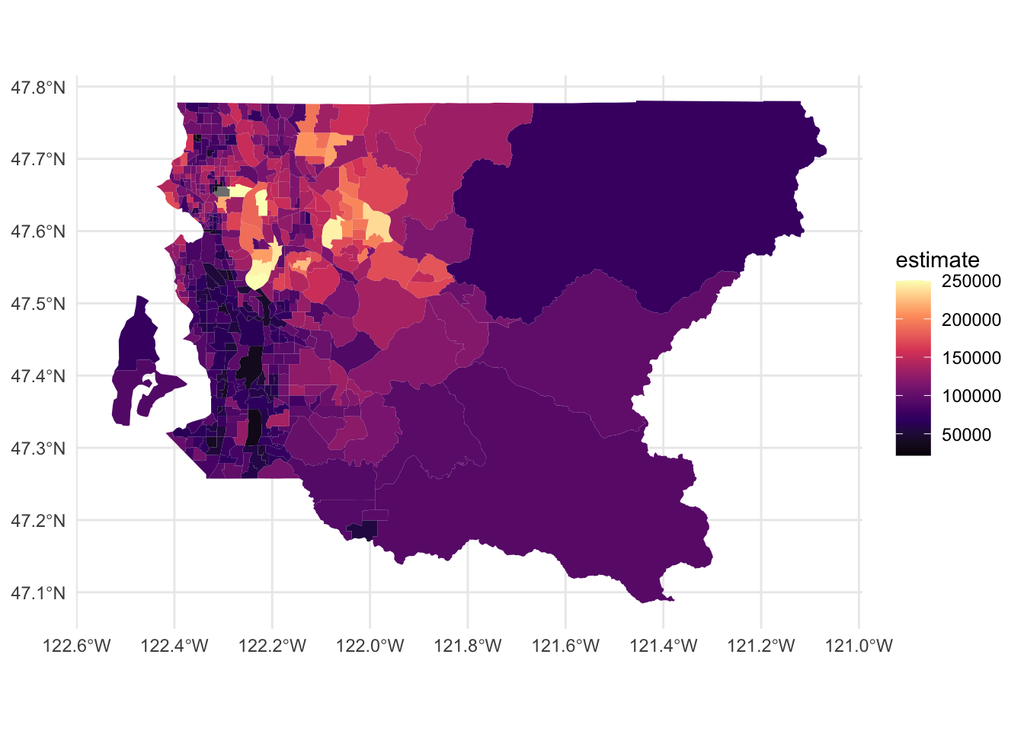

```r
king %>%
  ggplot(aes(fill = estimate)) + #the fill is the variable you wish to map
  geom_sf(color = NA) +  #develop some intuition: you should test out what happens when you don't set color=NA
  scale_fill_viridis_c(option = "magma") #the viridis package is a great option for mapping continuous data
```

## Question 0

Fill in `[YOUR CODE HERE]` with the correct R code.

### Question 0.1

Let’s look at the tracts for `Deschutes` county Oregon.

YOUR SOLUTION HERE

```r
deschutes <- get_acs(state = "OR",
                  county = "Deschutes",
                  geography = "tract",
                  variables = "B19013_001",
                  geometry = TRUE, #when you set it to TRUE you get a geometry column
                  year = 2020)
```

END OF YOUR SOLUTION HERE

### Question 0.2

YOUR SOLUTION HERE

```r
deschutes%>%head(6)
```

```
## Simple feature collection with 6 features and 5 fields
## Geometry type: MULTIPOLYGON
## Dimension:     XY
## Bounding box:  xmin: -121.3639 ymin: 43.98739 xmax: -121.2427 ymax: 44.06591
## Geodetic CRS:  NAD83
##         GEOID                                         NAME   variable estimate
## 1 41017002001 Census Tract 20.01, Deschutes County, Oregon B19013_001   100560
## 2 41017001801 Census Tract 18.01, Deschutes County, Oregon B19013_001    37650
## 3 41017001904 Census Tract 19.04, Deschutes County, Oregon B19013_001    81887
## 4 41017001501 Census Tract 15.01, Deschutes County, Oregon B19013_001    45714
## 5 41017002103 Census Tract 21.03, Deschutes County, Oregon B19013_001    94617
## 6 41017002102 Census Tract 21.02, Deschutes County, Oregon B19013_001    93438
##     moe                       geometry
## 1 20693 MULTIPOLYGON (((-121.3334 4...
## 2  7508 MULTIPOLYGON (((-121.2933 4...
## 3 30110 MULTIPOLYGON (((-121.284 44...
## 4  5088 MULTIPOLYGON (((-121.3205 4...
## 5 23431 MULTIPOLYGON (((-121.3638 4...
## 6 31692 MULTIPOLYGON (((-121.3637 4...
```

END OF YOUR SOLUTION HERE

### Question 0.3

YOUR SOLUTION HERE

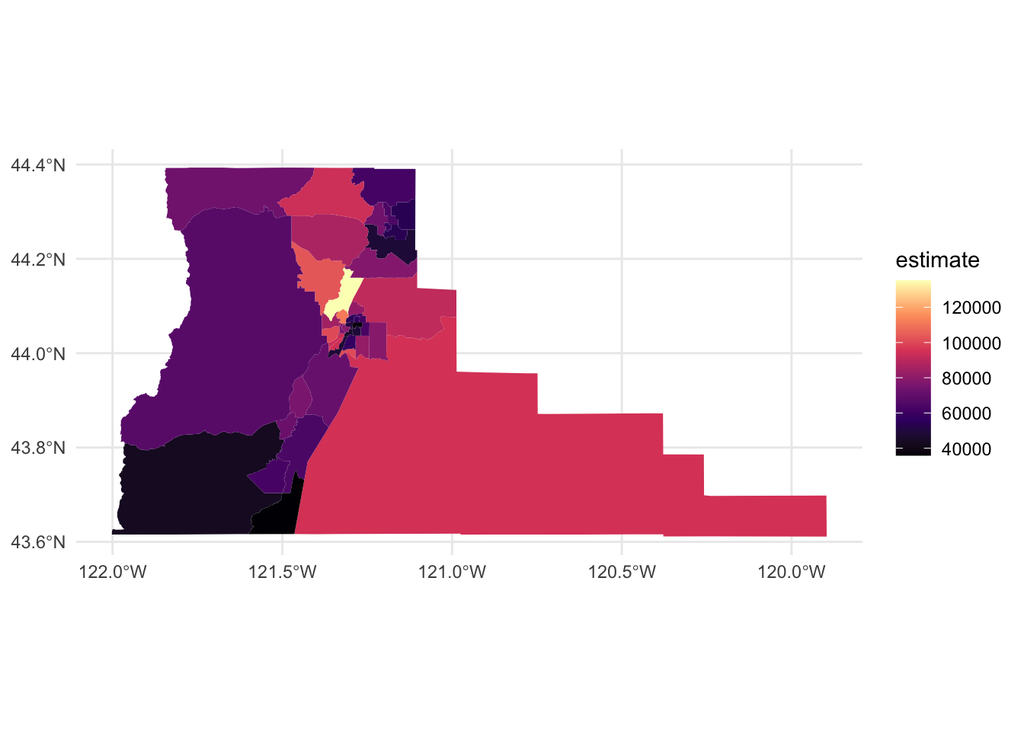

```r
deschutes %>%
  ggplot(aes(fill = estimate)) + #the fill is the variable you wish to map
  geom_sf(color = NA) +  #develop some intuition: you should test out what happens when you don't set color=NA
  scale_fill_viridis_c(option = "magma")
```

END OF YOUR SOLUTION HERE

### Question 0.4

```r
v20 <- load_variables(2020, "acs5", cache = TRUE)
# try View in the console
```

END OF YOUR SOLUTION HERE

END OF YOUR SOLUTION HERE

### Question 0.4

YOUR SOLUTION HERE

```r
vars<-c(
  median_age_male = "B01002_002",
  median_age_female="B01002_003",
  total_pop = "B01003_001",
  medincome = "B19013_001"
)

deschutes <- get_acs(state = "OR",
                  county = "Deschutes",
                  geography = "tract",
                  variables = vars,
                  geometry = TRUE, #when you set it to TRUE you get a geometry column
                  year = 2020)
head(deschutes)
```

```
## Simple feature collection with 6 features and 5 fields
## Geometry type: MULTIPOLYGON
## Dimension:     XY
## Bounding box:  xmin: -121.3334 ymin: 43.98792 xmax: -121.2638 ymax: 44.06591
## Geodetic CRS:  NAD83
##         GEOID                                         NAME          variable
## 1 41017002001 Census Tract 20.01, Deschutes County, Oregon   median_age_male
## 2 41017002001 Census Tract 20.01, Deschutes County, Oregon median_age_female
## 3 41017002001 Census Tract 20.01, Deschutes County, Oregon         total_pop
## 4 41017002001 Census Tract 20.01, Deschutes County, Oregon         medincome
## 5 41017001801 Census Tract 18.01, Deschutes County, Oregon   median_age_male
## 6 41017001801 Census Tract 18.01, Deschutes County, Oregon median_age_female
##   estimate     moe                       geometry
## 1     62.1    11.9 MULTIPOLYGON (((-121.3334 4...
## 2     57.8    14.2 MULTIPOLYGON (((-121.3334 4...
## 3   1400.0   453.0 MULTIPOLYGON (((-121.3334 4...
## 4 100560.0 20693.0 MULTIPOLYGON (((-121.3334 4...
## 5     35.3     3.7 MULTIPOLYGON (((-121.2933 4...
## 6     44.5     9.7 MULTIPOLYGON (((-121.2933 4...
```

END OF YOUR SOLUTION HERE

### Question 0.5

YOUR SOLUTION HERE

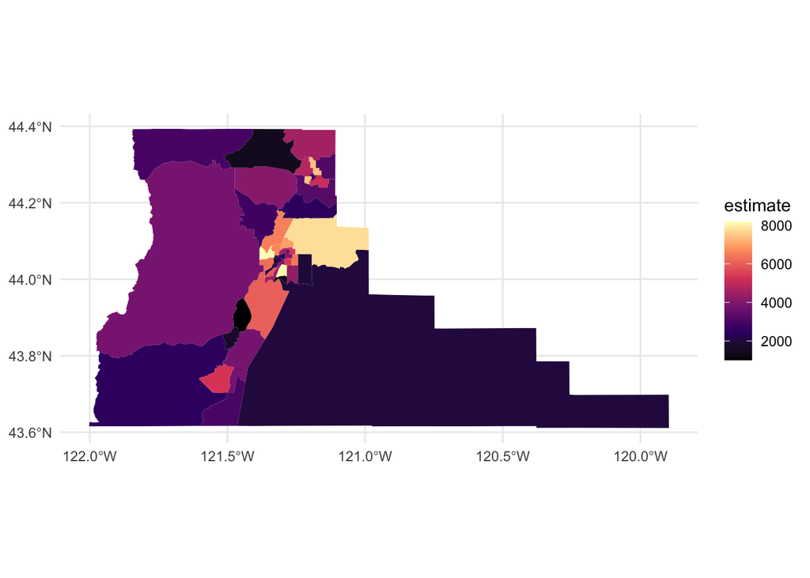

```r
deschutes%>%filter(variable=="total_pop") %>%
  ggplot(aes(fill = estimate)) + #the fill is the variable you wish to map
  geom_sf(color = NA) +  #develop some intuition: you should test out what happens when you don't set color=NA
  scale_fill_viridis_c(option = "magma")
```

END OF YOUR SOLUTION HERE